# Data Processing Example

ROBIN Network

2022-06-28

# Plan

- Data format (columns: Agency, Station, Day, Flow, Flag)
- Check for Level-1/Level-2 status based on completeness.
- Summary statistics
  - Monthly thresholds
  - POT series
  - 30-day/10-day/7-day rolling totals
  - Annual/monthly/quarterly quantiles/mean
  - Annual 1-day/10-day/30-day maxima
  - Annual 7-day/30-day minima
- Tests
  - Pettitt breakpoint test
  - Seasonal Mann-Kendall
  - Rolling Mann-Kendall-Snyers Indicators
- SSI
- Intermittence
- Mean Annual Flow (Standardised)
- Aridity Index

# Read in data

First the data must be read in, hopefully in the pre-specified format. The only addition required is the addition of any other flags to the `Flag` field. Currently there are:

- M: Missing value. Should correspond to an `NA`, `0`, or empty value `""` in the Value column.
- E: Estimated (or modelled) value
- S: Suspect value, may have high associated error.

Dates should be consistent, either with a full date (e.g. `2022-04-01`), or a full date and time (e.g. `2022-04-01T09:00:00Z`)

```r
filein_path <- "./41022_gdf.csv"
date_format <- "date" # state "date" or "datetime"

data_in <- read_in_robin(filein_path, skip=21)
data_in$Agency <- "EA"
data_in$Station <- 41022
```

## Check data type

All the data should be gauged daily flow.

```r
check_for_level(data_in, "M")
```

```
## [1] "Suitable for trend analysis"
```

```
## $stationLevel
## [1] 1
##
## $trendFlag
## [1] TRUE
```

# Reformat data

Dates are reformatted into a datetime variable, and a numerical record ordering is added. QA flags are converted to a factor form. Data without issue should have empty `QA_Flag` fields.

```r
data_in$id <- seq(1, nrow(data_in)) # does not account for missing rows in the data
data_in$Flag <- factor(data_in$Flag)

# Make the lfstat object
lf_flow <- data_in
DAY <- lf_flow$Day
lf_flow$day <- lubridate::day(lf_flow$Day)
lf_flow$month <- lubridate::month(lf_flow$Day)
lf_flow$year <- lubridate::year(lf_flow$Day)
lf_flow$flow <- lf_flow$Flow
lf_flow <- lf_flow[,c("day", "month", "year", "flow")]

year_start_month <- 10
lf_flow <- lfstat::createlfobj(lf_flow, hyearstart=year_start_month)
lf_flow$date <- DAY
```

# Derive flow statistics

## High Flow

### AMAX

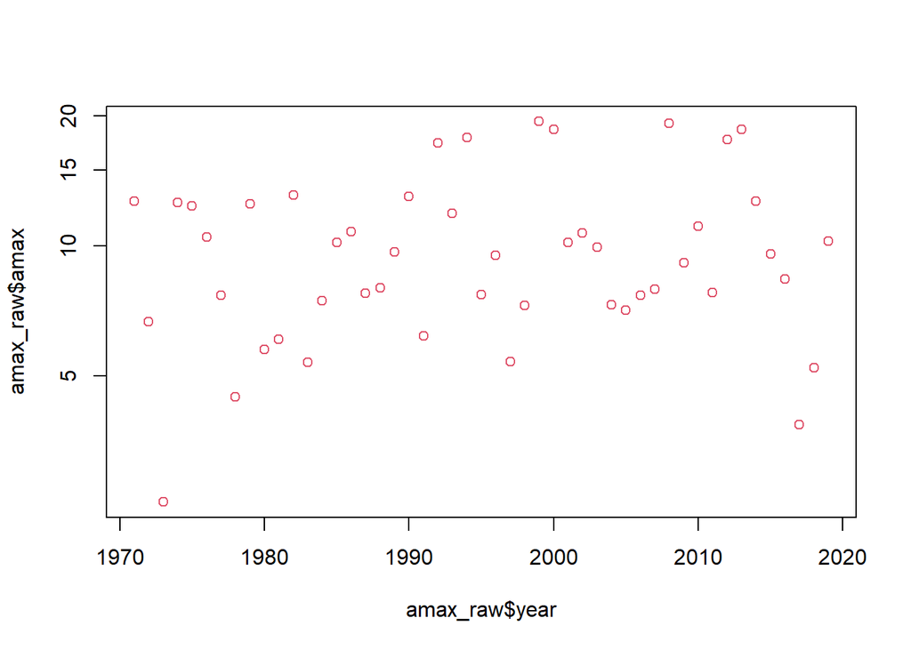

```r
MIN_DAYS_PER_YEAR <- 300 # Need to agree on.
data_in$year <- lubridate::year(data_in$Day)
amax_raw <- data_in %>%
  group_by(year) %>%
  summarise(count=n(), amax=max(Flow, na.rm=T), doy=which.max(Flow)) %>%
  dplyr::filter(count > MIN_DAYS_PER_YEAR)

plot(amax_raw$year, amax_raw$amax, type='p', col=2, log='y')
```

### Peaks-over-Threshold

```r
vmt_pot <- lfstat::vary_threshold(lf_flow,
                      varying="monthly",
                      fun=function(x){quantile(x, probs=c(0.986))})
```

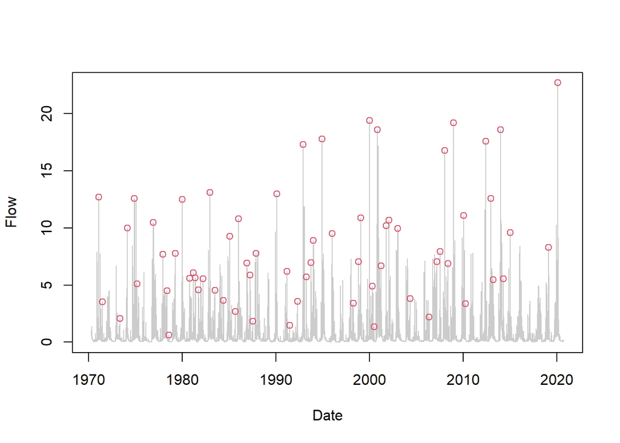

```r
lf_flow$threshold <- as.vector(vmt_pot)

vmt_summary <- lf_flow %>% group_by(month) %>% summarise(threshold=mean(threshold))

peaks <- ilaprosUtils::extractPeaks(vecObs=lf_flow$flow)
pots <- lf_flow[((lf_flow$flow > lf_flow$threshold) & (peaks==1)), ]
plot(lf_flow$date, lf_flow$flow, col="grey80", type='l', xlab="Date", ylab="Flow")
points(pots$date, pots$flow, col=2)
```

## Low flow

### Percentiles of flow

```r
flow_quantiles <- lfstat::Qxx(lf_flow, c(5, 70, 90, 95))
yearly_quantiles <- lfstat::Qxx(lf_flow, c(5,70,90,95), yearly=TRUE)
```

### Drought events

```r
vmt_drought <- lfstat::vary_threshold(lf_flow,
                      varying="monthly",
                      fun=function(x){quantile(x, probs=c(0.2))})
droughts <- lfstat::find_droughts(lf_flow, vmt_drought, varying="monthly")
```

```r
plot(droughts)
```

[interactive chart not shown]

```r
summary(droughts)
```

```
## Summary of droughts
## River:  at
## Units: volumes in m³, duration in days
##
## Filtered 294 minor events of 504 total.
## Only droughts with volume >= 2129.242 m³ and duration >= 5 days are reported.
##
##     event.no      start       time        end    volume duration dbt  qmin
## 1          1 1970-07-10 1970-07-14 1970-07-14   8294.40        5   5 0.028
## 4          4 1970-08-01 1970-08-05 1970-08-05   5097.60        5   5 0.038
## 5          5 1970-08-11 1970-08-18 1970-08-18   8553.60        8   8 0.039
## 6          6 1970-08-29 1970-09-09 1970-09-09   8380.80       12  12 0.033
## 7          7 1970-10-01 1970-10-06 1970-10-06   6739.20        6   6 0.061
## 8          8 1970-10-08 1970-11-01 1970-11-01  55814.40       25  25 0.054
## 10        10 1970-12-14 1970-12-29 1970-12-29 121824.00       16  16 0.101
```

[output cut: 414 more lines]

### N-day minima??

```r
mean_annual_min_7 <- lfstat::MAM(lf_flow, 7)
mean_annual_min_30 <- lfstat::MAM(lf_flow, 30)
mean_flow <- lfstat::meanflow(lf_flow)
```

# Trend analysis and plots

## Check for breakpoints

```r
pt <- trend::pettitt.test(x=lf_flow$flow)
sc <- strucchange::sctest(flow~date, data=lf_flow)
pel <- changepoint::cpt.meanvar(lf_flow$flow, minseglen=300, test.stat="Gamma")
```

## Check for autocorrelation

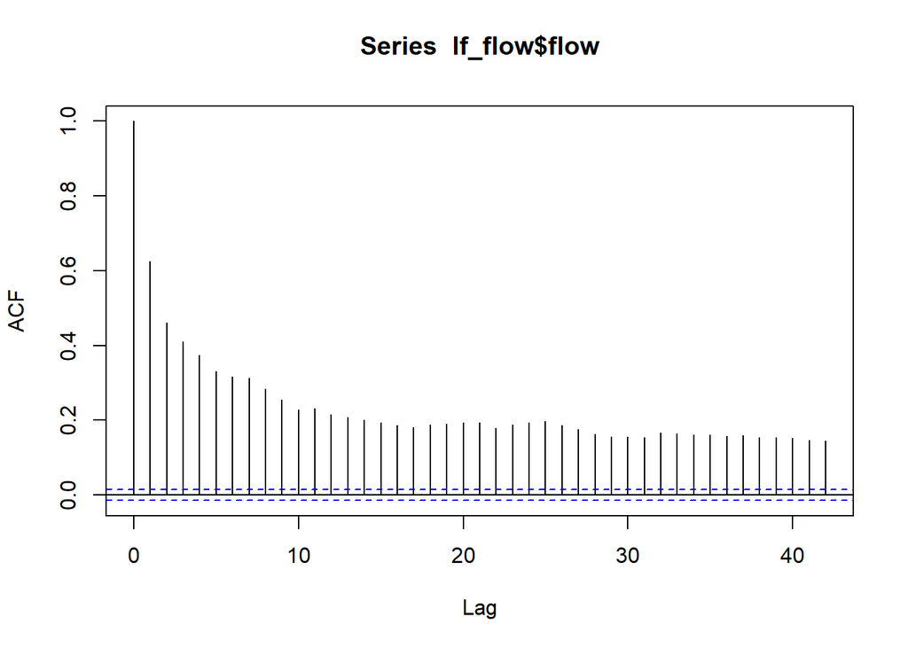

```r
daily_autocor <- acf(lf_flow$flow)
```

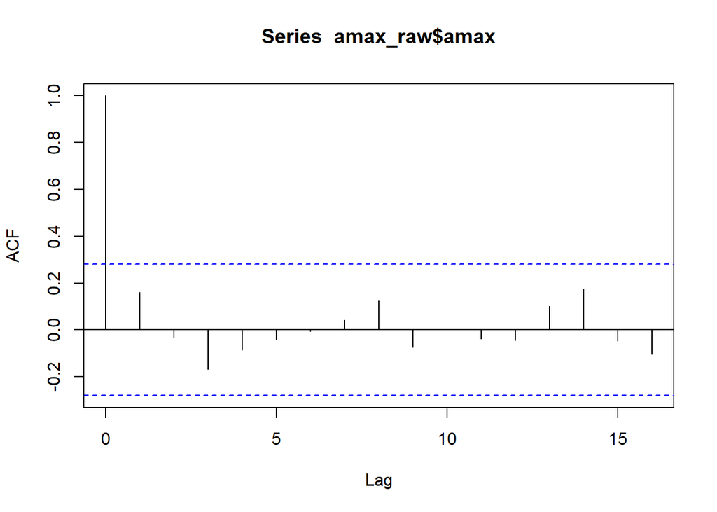

```r
amax_autocor <- acf(amax_raw$amax)
```

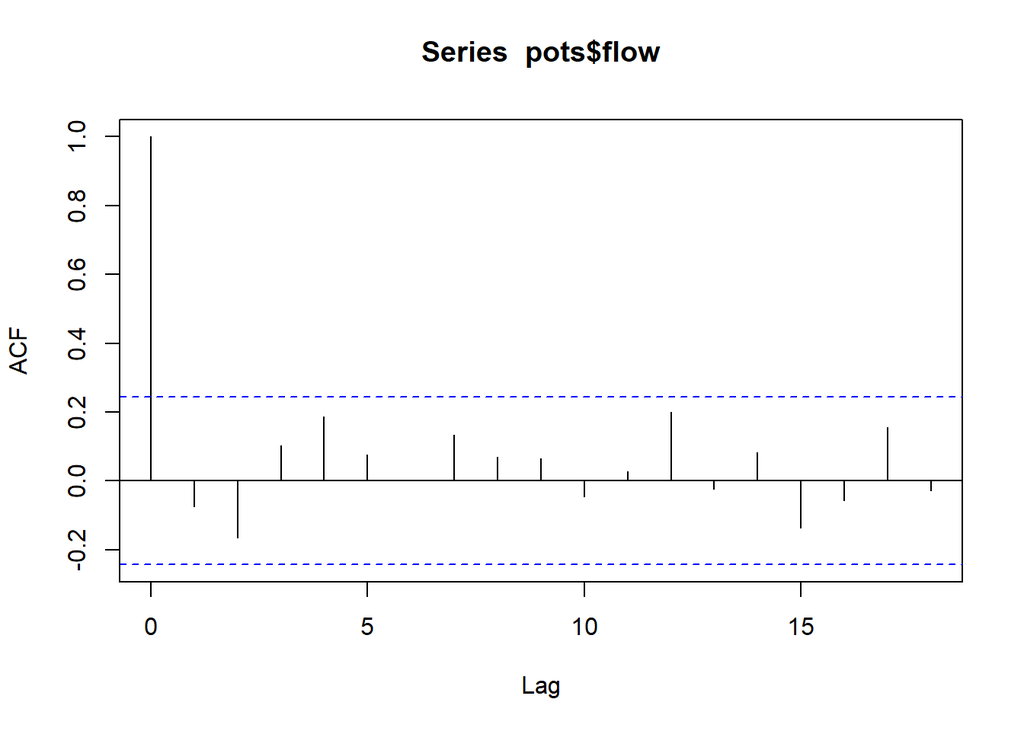

```r
pot_autocor <- acf(pots$flow)
```

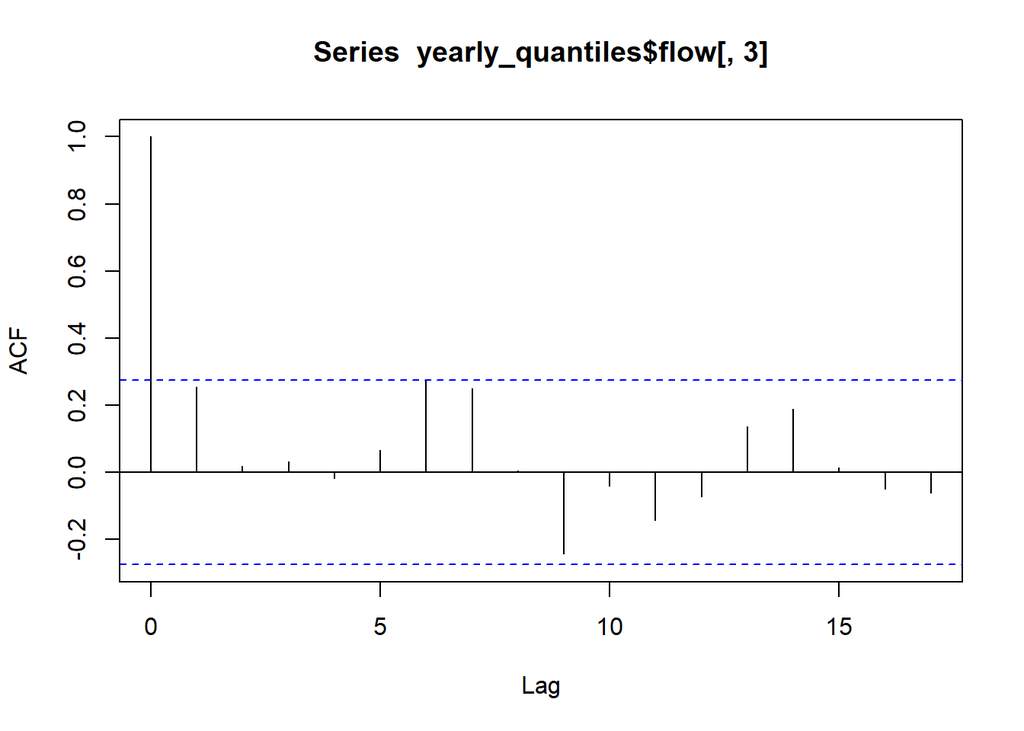

```r
low_autocor <- acf(yearly_quantiles$flow[,3])
```

## Mann-Kendall Tests

```r
# MK
# Seasonal
# MKSneyers
# Multi-temporal
```

## Theil-Sen slope

```r
# Basic
# Normalised (by mean/record length)
```

## Temporal clustering

### Droughts

### POT events

## Trends in timing

### 7-day minima/droughts

### AMAX/POT